# How to make a Financial Times Plot with ggplot2 in R?

Author

Ozancan Ozdemir

Hello folks!

In this tutorial, I will illustrate how to draw a Financial Times plot with `ggplot2` in R step by step. We know `ggthemes` package includes a theme related to Financial Times, but the theme is depreciated now.

My reference graph for this tutorial is given [below.](https://pbs.twimg.com/media/Fb9TWGQXgAAQmC4?format=jpg&name=900x900)

[figure not shown]

In order to draw a plot having a similar pattern with above one, I will use only `ggplot2` and `ggpubr` packages. Texts are from windows family. I do not import any extra fonts.

Let’s get started.

I will draw an inflation rate of Turkey. You can access the data from [here.](https://www.tcmb.gov.tr/wps/wcm/connect/TR/TCMB+TR/Main+Menu/Istatistikler/Enflasyon+Verileri/Tuketici+Fiyatlari)

Let’s read data at first.

```r
inflation<-readxl::read_xlsx("inflation_rate.xlsx")
head(inflation)
```

```
# A tibble: 6 x 2
  Date                 Rate
  <dttm>              <dbl>
1 2005-01-01 00:00:00  9.24
2 2005-02-01 00:00:00  8.69
3 2005-03-01 00:00:00  7.94
4 2005-04-01 00:00:00  8.18
5 2005-05-01 00:00:00  8.7
6 2005-06-01 00:00:00  8.95
```

Then, draw a line plot using `geom_line` geometric function.

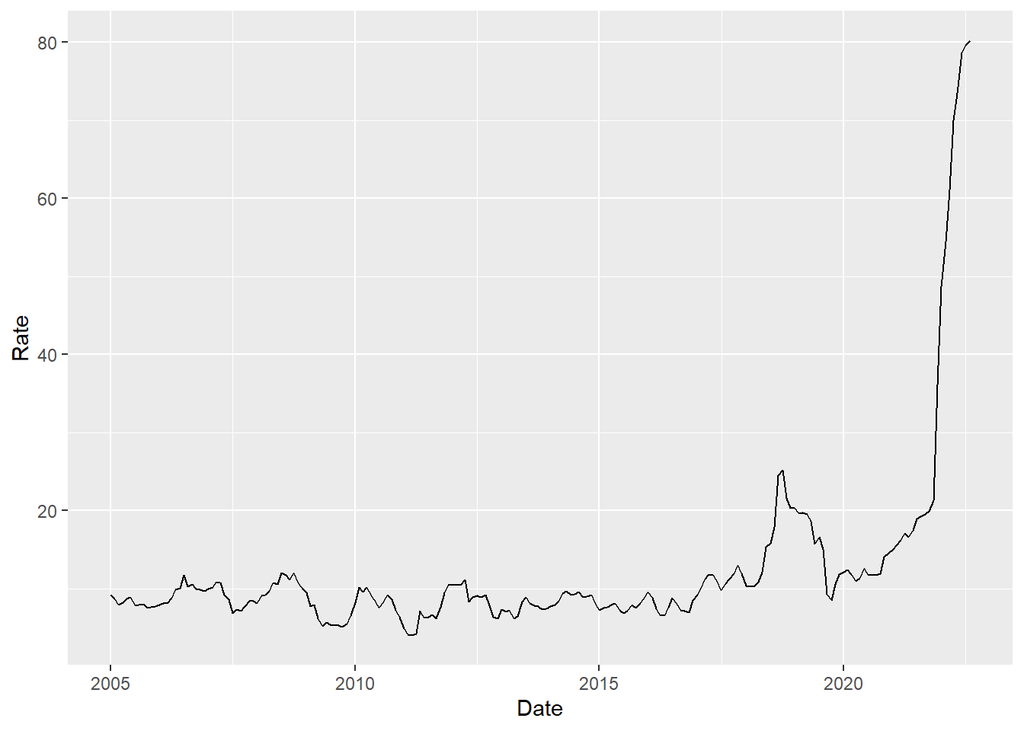

```r
library(ggplot2)
ggplot(inflation,aes(x = Date,
                     y = Rate))+
  geom_line()
```

Now, we will start to manipulate the appearance of the plot by adding title and caption.

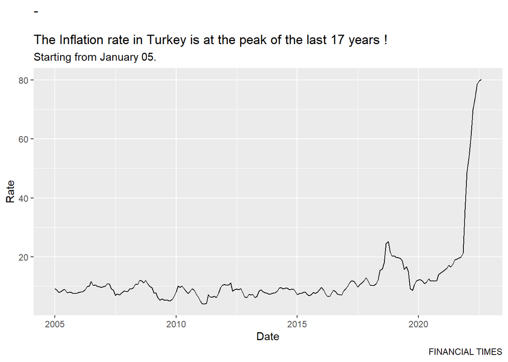

```r
ggplot(inflation,aes(x = Date,
                     y = Rate))+
  geom_line()+
  labs(title = "-

The Inflation rate in Turkey is at the peak of the last 17 years !",
       subtitle = "Starting from January 05.",
       caption = "FINANCIAL TIMES")
```

Then, change the background color, change the color and tickness of the line and remove the vertical grid lines. We will use `theme`function in `ggplot2` and `col` and `size`arguments in `geom_line` function.

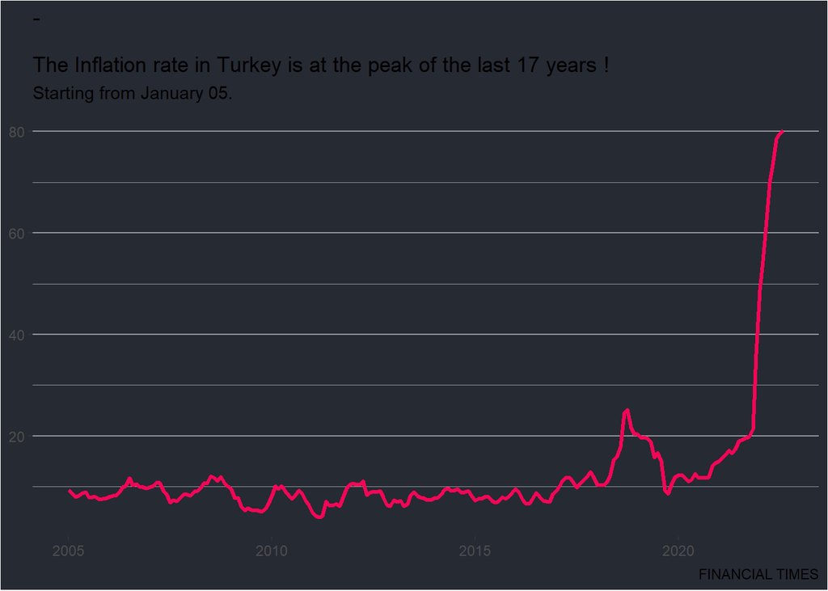

```r
ggplot(inflation,aes(x = Date,
                     y = Rate))+
  geom_line(col = "#f20656", size = 1.2)+
  labs(title = "-

The Inflation rate in Turkey is at the peak of the last 17 years !",
       subtitle = "Starting from January 05.",
       caption = "FINANCIAL TIMES")+
 theme(rect = element_rect(fill = "#262a33"),
        panel.background = element_rect(fill = "#262a33"),
        panel.grid.minor.x = element_blank(),
        panel.grid.major.x = element_blank(),
        panel.grid = element_line(color = "#92959e"),
        axis.title = element_blank())
```

After that, we will manipulate the texts on the plot. In other words, we will change the color and family of the texts. We will add the necessary arguments in `theme` function.

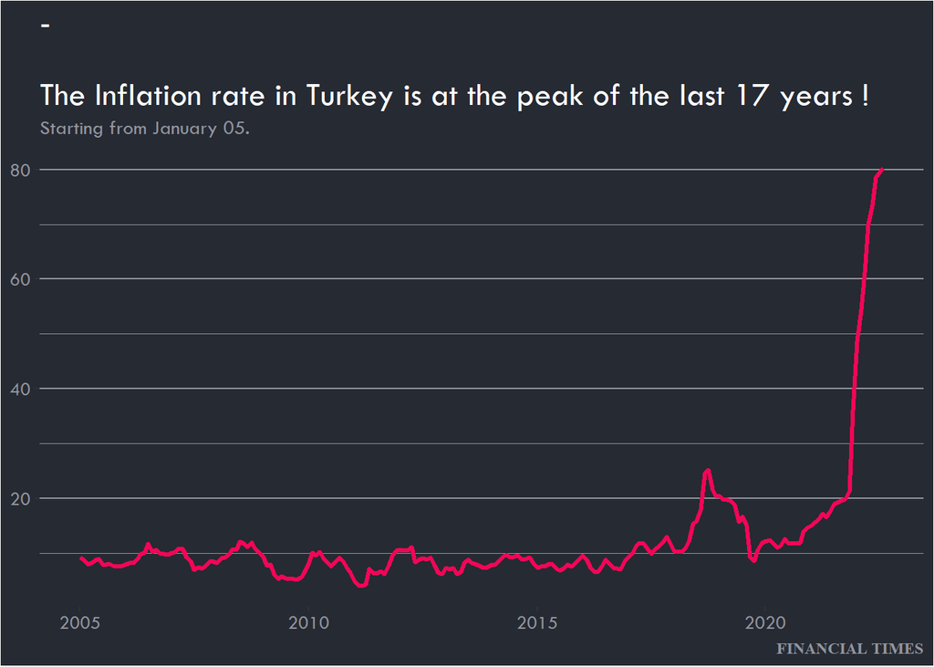

```r
ggplot(inflation,aes(x = Date,
                     y = Rate))+
  geom_line(col = "#f20656", size = 1.2)+
  labs(title = "-

The Inflation rate in Turkey is at the peak of the last 17 years !",
       subtitle = "Starting from January 05.",
       caption = "FINANCIAL TIMES")+
 theme(rect = element_rect(fill = "#262a33"),
        panel.background = element_rect(fill = "#262a33"),
        panel.grid.minor.x = element_blank(),
        panel.grid.major.x = element_blank(),
        panel.grid = element_line(color = "#92959e"),
        axis.title = element_blank(),
        plot.title = element_text(family ="Tw Cen MT", color = "white",size = 18),
       plot.subtitle = element_text(family ="Tw Cen MT", color = "#92959e"),
        plot.caption = element_text(family = "Times New Roman",face = "bold",color ="#92959e"),
       axis.text = element_text(size = 10, color ="#92959e", family = "Tw Cen MT"))
```

Next, we’ll put the y-axis values to the right of the graph. Also, we will paste **%** sign next to the values by using `scale_y_continuous` function.

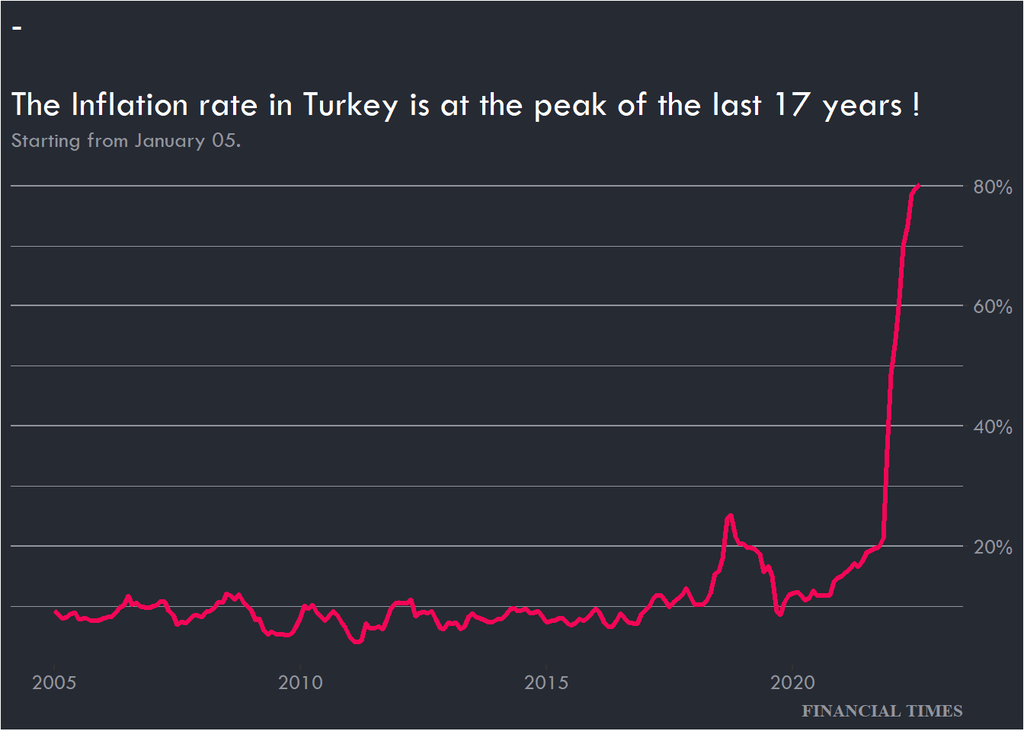

```r
ggplot(inflation,aes(x = Date,
                     y = Rate))+
  geom_line(col = "#f20656", size = 1.2)+
  labs(title = "-

The Inflation rate in Turkey is at the peak of the last 17 years !",
       subtitle = "Starting from January 05.",
       caption = "FINANCIAL TIMES")+
 theme(rect = element_rect(fill = "#262a33"),
        panel.background = element_rect(fill = "#262a33"),
        panel.grid.minor.x = element_blank(),
        panel.grid.major.x = element_blank(),
        panel.grid = element_line(color = "#92959e"),
        axis.title = element_blank(),
        plot.title = element_text(family ="Tw Cen MT", color = "white",size = 18),
       plot.subtitle = element_text(family ="Tw Cen MT", color = "#92959e"),
        plot.caption = element_text(family = "Times New Roman",face = "bold",color ="#92959e"),
       axis.text = element_text(size = 10, color ="#92959e", family = "Tw Cen MT"))+
  scale_y_continuous(labels = function(x) paste0(x, "%"),position = "right")
```

Lastly, we will add the second caption on the lower left corner of the plot, which may be the hardest part of this process. For this purpose, we will use `annotate_custom` function. We know that the input of this function is **grob** object. Thus, we will consider `ggpubr` package to produce a grob text object. Then, we will clip off using `coord_cartesian`.

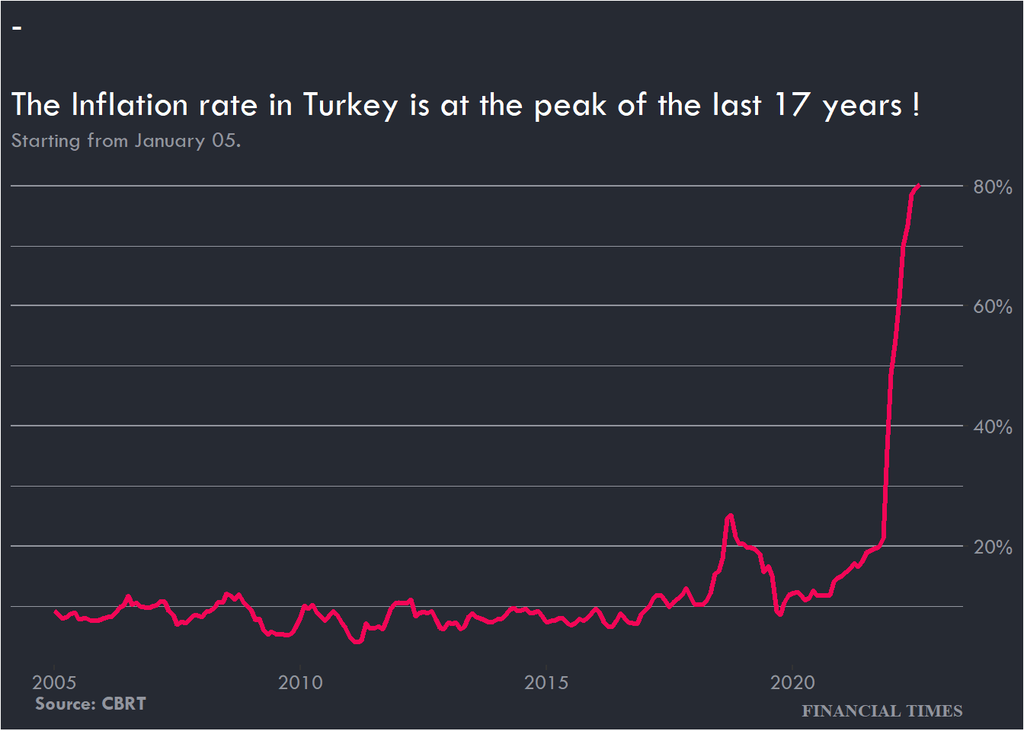

```r
caption2<-ggpubr::text_grob("Source: CBRT", family = "Tw Cen MT",face = "bold", color = "#92959e", size =10)

ggplot(inflation,aes(x = Date,
                     y = Rate))+
  geom_line(col = "#f20656", size = 1.2)+
  labs(title = "-

The Inflation rate in Turkey is at the peak of the last 17 years !",
       subtitle = "Starting from January 05.",
       caption = "FINANCIAL TIMES")+
 theme(rect = element_rect(fill = "#262a33"),
        panel.background = element_rect(fill = "#262a33"),
        panel.grid.minor.x = element_blank(),
        panel.grid.major.x = element_blank(),
        panel.grid = element_line(color = "#92959e"),
        axis.title = element_blank(),
        plot.title = element_text(family ="Tw Cen MT", color = "white",size = 18),
       plot.subtitle = element_text(family ="Tw Cen MT", color = "#92959e"),
        plot.caption = element_text(family = "Times New Roman",face = "bold",color ="#92959e"),
       axis.text = element_text(size = 10, color ="#92959e", family = "Tw Cen MT"))+
  scale_y_continuous(labels = function(x) paste0(x, "%"),position = "right")+
  annotation_custom(caption2,xmin=inflation$Date[10],xmax=inflation$Date[10],ymin=-6,ymax=-6)+
  coord_cartesian(clip = "off")
```

That’s it! If you wish to use this theme as a ggplot object, you can contact me via e-mail.

###### This document is prepared by Quarto.